# Associations with DN Regulation

#### RRS SubScales

##### Multiple Regression

Only the RRS Brooding is significant here. I am not sure why subject 5 is chosen as an outlier here.

```r
names <- c("RRS_Brooding", "RRS_Reflection", "RRS_Depression")
brainbehavior.multiple(names)
```

```
##
## Call:
## lmrob(formula = f, data = df, maxit.scale = 500)
##
## Weighted Residuals:
##       Min        1Q    Median        3Q       Max
## -0.047243 -0.020432 -0.000989  0.027870  0.314537
##
## Coefficients:
##                 Estimate Std. Error t value Pr(>|t|)
## (Intercept)     0.225500   0.065991    3.42  0.01419 *
## Age            -0.028091   0.003653   -7.69  0.00025 ***
## SexMale        -0.125407   0.044672   -2.81  0.03087 *
## RRS_Brooding    0.083479   0.010451    7.99  0.00021 ***
## RRS_Reflection -0.000753   0.004454   -0.17  0.87124
## RRS_Depression -0.002556   0.003112   -0.82  0.44272
## ---
## Signif. codes:  0 '***' 0.001 '**' 0.01 '*' 0.05 '.' 0.1 ' ' 1
##
## Robust residual standard error: 0.0608
## Convergence in 9 IRWLS iterations
##
## Robustness weights:
##  observation 5 is an outlier with |weight| = 0 ( < 0.0083);
##  3 weights are ~= 1. The remaining 8 ones are
##     1     2     3     4     7    10    11    12
## 0.998 0.991 0.985 0.946 0.962 0.882 0.986 0.962
## Algorithmic parameters:
## tuning.chi         bb tuning.psi refine.tol    rel.tol  solve.tol
##   1.55e+00   5.00e-01   4.69e+00   1.00e-07   1.00e-07   1.00e-07
##      nResample         max.it       best.r.s       k.fast.s          k.max
##            500             50              2              1            200
##    maxit.scale      trace.lev            mts     compute.rd fast.s.large.n
##            500              0           1000              0           2000
##           psi   subsampling        method           cov
##    "bisquare" "nonsingular"          "MM" ".vcov.avar1"
## seed : int(0)
```

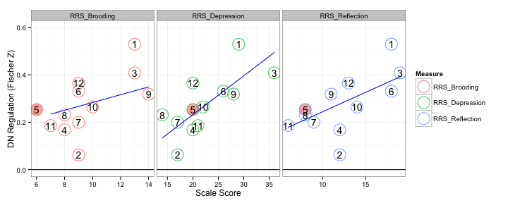

##### Single Regressions

I am not sure why it crashes with RRS_Reflection. It doesn't converge in the RRS Reflection case but from what I can tell there is nothing weird about this data.

```r
names <- c("RRS_Brooding", "RRS_Depression", "RRS_Reflection")
brainbehavior.single(names)
```

```
##
## Running regression for RRS_Brooding
##
## Call:
## lmrob(formula = f, data = df, maxit.scale = 500)
##
## Weighted Residuals:
##      Min       1Q   Median       3Q      Max
## -0.05124 -0.02476  0.00818  0.02299  0.28660
##
## Coefficients:
##              Estimate Std. Error t value Pr(>|t|)
## (Intercept)   0.19299    0.04810    4.01   0.0039 **
## Age          -0.02588    0.00264   -9.81  9.8e-06 ***
## SexMale      -0.11872    0.03117   -3.81   0.0052 **
## RRS_Brooding  0.07443    0.00570   13.07  1.1e-06 ***
## ---
## Signif. codes:  0 '***' 0.001 '**' 0.01 '*' 0.05 '.' 0.1 ' ' 1
##
## Robust residual standard error: 0.0585
## Convergence in 8 IRWLS iterations
##
## Robustness weights:
##  observation 5 is an outlier with |weight| = 0 ( < 0.0083);
##  one weight is ~= 1. The remaining 10 ones are
##     1     2     3     4     6     7     8    10    11    12
## 0.994 0.985 0.961 0.931 0.995 0.981 0.996 0.885 0.994 0.945
## Algorithmic parameters:
## tuning.chi         bb tuning.psi refine.tol    rel.tol  solve.tol
##   1.55e+00   5.00e-01   4.69e+00   1.00e-07   1.00e-07   1.00e-07
##      nResample         max.it       best.r.s       k.fast.s          k.max
##            500             50              2              1            200
##    maxit.scale      trace.lev            mts     compute.rd fast.s.large.n
##            500              0           1000              0           2000
##           psi   subsampling        method           cov
##    "bisquare" "nonsingular"          "MM" ".vcov.avar1"
## seed : int(0)
##
##
## Running regression for RRS_Depression
```

[output cut: 22 more lines]

```
##    Min. 1st Qu.  Median    Mean 3rd Qu.    Max.
##   0.847   0.933   0.968   0.955   0.993   0.997
## Algorithmic parameters:
## tuning.chi         bb tuning.psi refine.tol    rel.tol  solve.tol
##   1.55e+00   5.00e-01   4.69e+00   1.00e-07   1.00e-07   1.00e-07
##      nResample         max.it       best.r.s       k.fast.s          k.max
##            500             50              2              1            200
##    maxit.scale      trace.lev            mts     compute.rd fast.s.large.n
##            500              0           1000              0           2000
##           psi   subsampling        method           cov
##    "bisquare" "nonsingular"          "MM" ".vcov.avar1"
## seed : int(0)
##
##
## Running regression for RRS_Reflection
```

```
## Error: missing value where TRUE/FALSE needed
```

#### SIPI SubScales

##### Multiple Regression

The Guilt and Fear of Failure of Day Dreaming questionnaire is marginally significant.

```r
names <- c("SIPI_PAC", "SIPI_GFFD", "SIPI_PCD")
brainbehavior.multiple(names)
```

```
##
## Call:
## lmrob(formula = f, data = df, maxit.scale = 500)
##
## Weighted Residuals:
##      Min       1Q   Median       3Q      Max
## -0.21059 -0.03714  0.00342  0.03413  0.20033
##
## Coefficients:
##             Estimate Std. Error t value Pr(>|t|)
## (Intercept)  0.91100    2.01806    0.45     0.67
## Age         -0.01317    0.02927   -0.45     0.67
## SexMale      0.01409    0.06075    0.23     0.82
## SIPI_PAC    -0.00383    0.01004   -0.38     0.72
## SIPI_GFFD    0.00619    0.00268    2.31     0.06 .
## SIPI_PCD    -0.00650    0.01707   -0.38     0.72
## ---
## Signif. codes:  0 '***' 0.001 '**' 0.01 '*' 0.05 '.' 0.1 ' ' 1
##
## Robust residual standard error: 0.112
## Convergence in 39 IRWLS iterations
##
## Robustness weights:
##    Min. 1st Qu.  Median    Mean 3rd Qu.    Max.
##   0.706   0.888   0.988   0.929   0.995   0.998
## Algorithmic parameters:
## tuning.chi         bb tuning.psi refine.tol    rel.tol  solve.tol
##   1.55e+00   5.00e-01   4.69e+00   1.00e-07   1.00e-07   1.00e-07
##      nResample         max.it       best.r.s       k.fast.s          k.max
##            500             50              2              1            200
##    maxit.scale      trace.lev            mts     compute.rd fast.s.large.n
##            500              0           1000              0           2000
##           psi   subsampling        method           cov
##    "bisquare" "nonsingular"          "MM" ".vcov.avar1"
## seed : int(0)
```

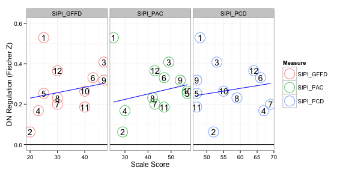

##### Single Regressions

None of them are significant!

```r
names <- c("SIPI_PAC", "SIPI_GFFD", "SIPI_PCD")
brainbehavior.single(names)
```

```
##
## Running regression for SIPI_PAC
##
## Call:
## lmrob(formula = f, data = df, maxit.scale = 500)
##
## Weighted Residuals:
##     Min      1Q  Median      3Q     Max
## -0.1467 -0.0818 -0.0176  0.0658  0.3003
##
## Coefficients:
##             Estimate Std. Error t value Pr(>|t|)
## (Intercept)  0.32095    0.30470    1.05     0.32
## Age         -0.00476    0.01106   -0.43     0.68
## SexMale      0.03912    0.06467    0.60     0.56
## SIPI_PAC     0.00107    0.00807    0.13     0.90
##
## Robust residual standard error: 0.134
## Convergence in 19 IRWLS iterations
##
## Robustness weights:
##  one weight is ~= 1. The remaining 11 ones are summarized as
##    Min. 1st Qu.  Median    Mean 3rd Qu.    Max.
##   0.596   0.942   0.963   0.929   0.987   0.995
## Algorithmic parameters:
## tuning.chi         bb tuning.psi refine.tol    rel.tol  solve.tol
##   1.55e+00   5.00e-01   4.69e+00   1.00e-07   1.00e-07   1.00e-07
##      nResample         max.it       best.r.s       k.fast.s          k.max
##            500             50              2              1            200
##    maxit.scale      trace.lev            mts     compute.rd fast.s.large.n
##            500              0           1000              0           2000
##           psi   subsampling        method           cov
##    "bisquare" "nonsingular"          "MM" ".vcov.avar1"
## seed : int(0)
##
##
## Running regression for SIPI_GFFD
##
## Call:
## lmrob(formula = f, data = df, maxit.scale = 500)
```

[output cut: 48 more lines]

```
## Convergence in 12 IRWLS iterations
##
## Robustness weights:
##    Min. 1st Qu.  Median    Mean 3rd Qu.    Max.
##   0.799   0.946   0.979   0.956   0.992   0.997
## Algorithmic parameters:
## tuning.chi         bb tuning.psi refine.tol    rel.tol  solve.tol
##   1.55e+00   5.00e-01   4.69e+00   1.00e-07   1.00e-07   1.00e-07
##      nResample         max.it       best.r.s       k.fast.s          k.max
##            500             50              2              1            200
##    maxit.scale      trace.lev            mts     compute.rd fast.s.large.n
##            500              0           1000              0           2000
##           psi   subsampling        method           cov
##    "bisquare" "nonsingular"          "MM" ".vcov.avar1"
## seed : int(0)
```

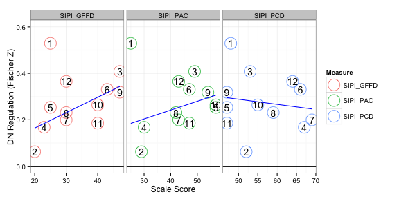

#### ERQ SubScales

##### Multiple Regression

Nothing.

```r
names <- c("ERQ_Reappraisal", "ERQ_Suppression")
brainbehavior.multiple(names)
```

```
##
## Call:
## lmrob(formula = f, data = df, maxit.scale = 500)
##
## Weighted Residuals:
##     Min      1Q  Median      3Q     Max
## -0.1329 -0.1078  0.0182  0.0493  0.2290
##
## Coefficients:
##                 Estimate Std. Error t value Pr(>|t|)
## (Intercept)      0.58711    0.52297    1.12     0.30
## Age             -0.01908    0.01714   -1.11     0.30
## SexMale          0.07467    0.06719    1.11     0.30
## ERQ_Reappraisal -0.00223    0.00690   -0.32     0.76
## ERQ_Suppression  0.01317    0.01057    1.25     0.25
##
## Robust residual standard error: 0.124
## Convergence in 15 IRWLS iterations
##
## Robustness weights:
##  one weight is ~= 1. The remaining 11 ones are summarized as
##    Min. 1st Qu.  Median    Mean 3rd Qu.    Max.
##   0.711   0.906   0.935   0.929   0.989   0.996
## Algorithmic parameters:
## tuning.chi         bb tuning.psi refine.tol    rel.tol  solve.tol
##   1.55e+00   5.00e-01   4.69e+00   1.00e-07   1.00e-07   1.00e-07
##      nResample         max.it       best.r.s       k.fast.s          k.max
##            500             50              2              1            200
##    maxit.scale      trace.lev            mts     compute.rd fast.s.large.n
##            500              0           1000              0           2000
##           psi   subsampling        method           cov
##    "bisquare" "nonsingular"          "MM" ".vcov.avar1"
## seed : int(0)
```

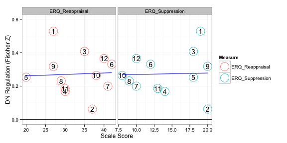

##### Single Regressions

The Reappraisal subscale was significant and it choose subject 2 as an outlier.

```r
names <- c("ERQ_Reappraisal", "ERQ_Suppression")
brainbehavior.single(names)
```

```
##
## Running regression for ERQ_Reappraisal
##
## Call:
## lmrob(formula = f, data = df, maxit.scale = 500)
##
## Weighted Residuals:
##      Min       1Q   Median       3Q      Max
## -0.48777 -0.04345 -0.01970  0.00877  0.22713
##
## Coefficients:
##                 Estimate Std. Error t value Pr(>|t|)
## (Intercept)      -0.6816     0.3847   -1.77    0.114
## Age               0.0272     0.0123    2.22    0.058 .
## SexMale          -0.0959     0.0854   -1.12    0.294
## ERQ_Reappraisal   0.0112     0.0042    2.68    0.028 *
## ---
## Signif. codes:  0 '***' 0.001 '**' 0.01 '*' 0.05 '.' 0.1 ' ' 1
##
## Robust residual standard error: 0.0856
## Convergence in 12 IRWLS iterations
##
## Robustness weights:
##  observation 2 is an outlier with |weight| = 0 ( < 0.0083);
##  2 weights are ~= 1. The remaining 9 ones are
##     1     3     4     7     8     9    10    11    12
## 0.461 0.684 0.910 0.990 0.998 0.968 0.982 0.979 0.992
## Algorithmic parameters:
## tuning.chi         bb tuning.psi refine.tol    rel.tol  solve.tol
##   1.55e+00   5.00e-01   4.69e+00   1.00e-07   1.00e-07   1.00e-07
##      nResample         max.it       best.r.s       k.fast.s          k.max
##            500             50              2              1            200
##    maxit.scale      trace.lev            mts     compute.rd fast.s.large.n
##            500              0           1000              0           2000
##           psi   subsampling        method           cov
##    "bisquare" "nonsingular"          "MM" ".vcov.avar1"
## seed : int(0)
##
##
## Running regression for ERQ_Suppression
```

[output cut: 19 more lines]

```
##
## Robustness weights:
##  one weight is ~= 1. The remaining 11 ones are summarized as
##    Min. 1st Qu.  Median    Mean 3rd Qu.    Max.
##   0.815   0.944   0.963   0.954   0.993   0.998
## Algorithmic parameters:
## tuning.chi         bb tuning.psi refine.tol    rel.tol  solve.tol
##   1.55e+00   5.00e-01   4.69e+00   1.00e-07   1.00e-07   1.00e-07
##      nResample         max.it       best.r.s       k.fast.s          k.max
##            500             50              2              1            200
##    maxit.scale      trace.lev            mts     compute.rd fast.s.large.n
##            500              0           1000              0           2000
##           psi   subsampling        method           cov
##    "bisquare" "nonsingular"          "MM" ".vcov.avar1"
## seed : int(0)
```

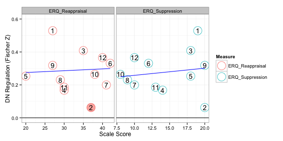

#### PANAS SubScales

##### Multiple Regression

Nothing.

```r
names <- c("PANAS_Positive", "PANAS_Negative")
brainbehavior.multiple(names)
```

```
##
## Call:
## lmrob(formula = f, data = df, maxit.scale = 500)
##
## Weighted Residuals:
##     Min      1Q  Median      3Q     Max
## -0.1215 -0.0579 -0.0104  0.0632  0.3438
##
## Coefficients:
##                Estimate Std. Error t value Pr(>|t|)
## (Intercept)     0.70880    0.52021    1.36     0.22
## Age            -0.01042    0.01421   -0.73     0.49
## SexMale         0.06298    0.07716    0.82     0.44
## PANAS_Positive -0.00726    0.00853   -0.85     0.42
## PANAS_Negative  0.00514    0.00725    0.71     0.50
##
## Robust residual standard error: 0.129
## Convergence in 16 IRWLS iterations
##
## Robustness weights:
##    Min. 1st Qu.  Median    Mean 3rd Qu.    Max.
##   0.456   0.970   0.978   0.933   0.986   0.996
## Algorithmic parameters:
## tuning.chi         bb tuning.psi refine.tol    rel.tol  solve.tol
##   1.55e+00   5.00e-01   4.69e+00   1.00e-07   1.00e-07   1.00e-07
##      nResample         max.it       best.r.s       k.fast.s          k.max
##            500             50              2              1            200
##    maxit.scale      trace.lev            mts     compute.rd fast.s.large.n
##            500              0           1000              0           2000
##           psi   subsampling        method           cov
##    "bisquare" "nonsingular"          "MM" ".vcov.avar1"
## seed : int(0)
```

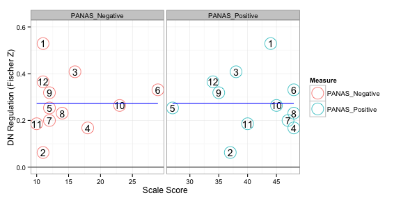

##### Single Regression

Nothing.

```r
names <- c("PANAS_Positive", "PANAS_Negative")
brainbehavior.single(names)
```

```
##
## Running regression for PANAS_Positive
##
## Call:
## lmrob(formula = f, data = df, maxit.scale = 500)
##
## Weighted Residuals:
##     Min      1Q  Median      3Q     Max
## -0.1375 -0.0693 -0.0103  0.0640  0.3111
##
## Coefficients:
##                Estimate Std. Error t value Pr(>|t|)
## (Intercept)     0.68186    0.54252    1.26     0.24
## Age            -0.01021    0.01596   -0.64     0.54
## SexMale         0.06289    0.09403    0.67     0.52
## PANAS_Positive -0.00474    0.00582   -0.82     0.44
##
## Robust residual standard error: 0.129
## Convergence in 13 IRWLS iterations
##
## Robustness weights:
##  one weight is ~= 1. The remaining 11 ones are summarized as
##    Min. 1st Qu.  Median    Mean 3rd Qu.    Max.
##   0.543   0.940   0.967   0.926   0.982   0.997
## Algorithmic parameters:
## tuning.chi         bb tuning.psi refine.tol    rel.tol  solve.tol
##   1.55e+00   5.00e-01   4.69e+00   1.00e-07   1.00e-07   1.00e-07
##      nResample         max.it       best.r.s       k.fast.s          k.max
##            500             50              2              1            200
##    maxit.scale      trace.lev            mts     compute.rd fast.s.large.n
##            500              0           1000              0           2000
##           psi   subsampling        method           cov
##    "bisquare" "nonsingular"          "MM" ".vcov.avar1"
## seed : int(0)
##
##
## Running regression for PANAS_Negative
##
## Call:
## lmrob(formula = f, data = df, maxit.scale = 500)
```

[output cut: 14 more lines]

```
##
## Robustness weights:
##  one weight is ~= 1. The remaining 11 ones are summarized as
##    Min. 1st Qu.  Median    Mean 3rd Qu.    Max.
##   0.733   0.958   0.964   0.948   0.992   0.996
## Algorithmic parameters:
## tuning.chi         bb tuning.psi refine.tol    rel.tol  solve.tol
##   1.55e+00   5.00e-01   4.69e+00   1.00e-07   1.00e-07   1.00e-07
##      nResample         max.it       best.r.s       k.fast.s          k.max
##            500             50              2              1            200
##    maxit.scale      trace.lev            mts     compute.rd fast.s.large.n
##            500              0           1000              0           2000
##           psi   subsampling        method           cov
##    "bisquare" "nonsingular"          "MM" ".vcov.avar1"
## seed : int(0)
```

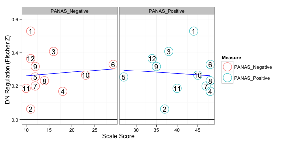

### with Phenotypic Measures but NO Age and Sex

```r
brainbehavior.multiple <- function(names, with_age_sex = TRUE) {
    # Significance
    if (with_age_sex)
        f <- paste("prediction ~ Age + Sex +", paste(names, collapse = " + ")) else f <- paste("prediction ~", paste(names, collapse = " + "))
    f <- as.formula(f)
    tdf <- wrap_lmrob(f, df)

    # Reorganize
    tdf$id <- 1:nrow(tdf)
    bb.df <- ddply(tdf, .(Subject), function(sdf) {
        sdf <- data.frame(sdf[rep(1, length(names)), c("id", "Subject", "prediction",
            "outlier", "weights")], measure = names, behavior = as.numeric(sdf[,
            names]))
        sdf
    })

    # Get best fit line
    model <- lmrob(prediction ~ behavior + measure, bb.df, maxit.scale = 500)
    grid <- ddply(bb.df[bb.df$outlier == "no", ], .(measure), function(sdf) {
        data.frame(behavior = seq(min(sdf$behavior), max(sdf$behavior), length = 20),
            measure = rep(sdf$measure[1], 20))
    })
    grid$prediction <- predict(model, newdata = grid)

    # Plot
    p0 <- ggplot(bb.df, aes(x = behavior, y = prediction)) + geom_hline(aes(yintercept = 0)) +
        ylim(0, 0.6) + xlab("Scale Score") + ylab("DN Regulation (Fischer Z)") +
        facet_grid(. ~ measure, scales = "free_x")
    if (any(bb.df$outlier == "yes")) {
        p <- p0 + geom_point(data = bb.df[bb.df$outlier == "yes", ], size = 8,
            color = brewer.pal(3, "Pastel1")[1]) + geom_point(aes(color = measure),
            shape = 1, size = 8) + geom_text(aes(label = id), size = 5) + geom_line(data = grid,
            color = "blue") + scale_color_discrete(name = "Measure")
    } else {
        p <- p0 + geom_point(aes(color = measure), shape = 1, size = 8) + geom_text(aes(label = id),
            size = 5) + geom_line(data = grid, color = "blue") + scale_color_discrete(name = "Measure")
    }
    p
}
brainbehavior.single <- function(names, with_age_sex = TRUE) {
    # Significance
    bb.df <- ldply(names, function(name) {
        cat("\nRunning regression for", name, "\n")
        if (with_age_sex)
            f <- paste("prediction ~ Age + Sex +", name) else f <- paste("prediction ~", name)
        f <- as.formula(f)
        tdf <- wrap_lmrob(f, df)
        tdf$id <- 1:nrow(tdf)
        tdf$measure <- name
        tdf$behavior <- tdf[[name]]
        cat("\n")
        tdf[, c("id", "Subject", "measure", "behavior", "prediction", "outlier",
            "weights")]
    })
    bb.df$measure <- factor(bb.df$measure)
    bb.df$outlier <- factor(bb.df$outlier)


    # Get best fit line
    grid <- ddply(bb.df[bb.df$outlier == "no", ], .(measure), function(sdf) {
        model <- lmrob(prediction ~ behavior, sdf, maxit.scale = 500)
        sgrid <- data.frame(behavior = seq(min(sdf$behavior), max(sdf$behavior),
            length = 20))
        sgrid$prediction <- predict(model, newdata = sgrid)
        sgrid$measure <- sdf$measure[1]
        sgrid
    })

    # Plot
    p0 <- ggplot(bb.df, aes(x = behavior, y = prediction)) + geom_hline(aes(yintercept = 0)) +
        ylim(0, 0.6) + xlab("Scale Score") + ylab("DN Regulation (Fischer Z)") +
        facet_grid(. ~ measure, scales = "free_x")
    if (any(bb.df$outlier == "yes")) {
        p <- p0 + geom_point(data = bb.df[bb.df$outlier == "yes", ], size = 8,
            color = brewer.pal(3, "Pastel1")[1]) + geom_point(aes(color = measure),
            shape = 1, size = 8) + geom_text(aes(label = id), size = 5) + geom_line(data = grid,
            color = "blue") + scale_color_discrete(name = "Measure")
    } else {
        p <- p0 + geom_point(aes(color = measure), shape = 1, size = 8) + geom_text(aes(label = id),
            size = 5) + geom_line(data = grid, color = "blue") + scale_color_discrete(name = "Measure")
    }
    p
}
```

#### Total Scale Scores (with BDI, without PANAS)

##### Multiple Regression

```r
names <- c("SIPI", "RRS", "ERQ", "BDI", "AIM")
brainbehavior.multiple(names, with_age_sex = FALSE)
```

```
##
## Call:
## lmrob(formula = f, data = df, maxit.scale = 500)
##
## Weighted Residuals:
##     Min      1Q  Median      3Q     Max
## -0.0954 -0.0406 -0.0142  0.0369  0.1255
##
## Coefficients:
##              Estimate Std. Error t value Pr(>|t|)
## (Intercept)  0.253335   0.233538    1.08   0.3197
## SIPI        -0.000843   0.001500   -0.56   0.5943
## RRS          0.009815   0.002457    4.00   0.0072 **
## ERQ         -0.009272   0.003912   -2.37   0.0555 .
## BDI          0.000570   0.006169    0.09   0.9295
## AIM          0.000934   0.001400    0.67   0.5294
## ---
## Signif. codes:  0 '***' 0.001 '**' 0.01 '*' 0.05 '.' 0.1 ' ' 1
##
## Robust residual standard error: 0.0921
## Convergence in 10 IRWLS iterations
##
## Robustness weights:
##  one weight is ~= 1. The remaining 11 ones are summarized as
##    Min. 1st Qu.  Median    Mean 3rd Qu.    Max.
##   0.838   0.940   0.973   0.955   0.989   0.994
## Algorithmic parameters:
## tuning.chi         bb tuning.psi refine.tol    rel.tol  solve.tol
##   1.55e+00   5.00e-01   4.69e+00   1.00e-07   1.00e-07   1.00e-07
##      nResample         max.it       best.r.s       k.fast.s          k.max
##            500             50              2              1            200
##    maxit.scale      trace.lev            mts     compute.rd fast.s.large.n
##            500              0           1000              0           2000
##           psi   subsampling        method           cov
##    "bisquare" "nonsingular"          "MM" ".vcov.avar1"
## seed : int(0)
```

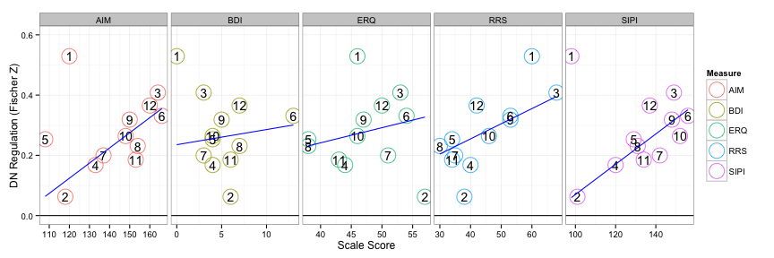

##### Single Regressions

```r
names <- c("SIPI", "RRS", "ERQ", "BDI", "AIM")
brainbehavior.single(names, with_age_sex = FALSE)
```

```
##
## Running regression for SIPI
##
## Call:
## lmrob(formula = f, data = df, maxit.scale = 500)
##
## Weighted Residuals:
##       Min        1Q    Median        3Q       Max
## -0.080078 -0.026553  0.000434  0.051478  0.464433
##
## Coefficients:
##              Estimate Std. Error t value Pr(>|t|)
## (Intercept) -0.414612   0.088319   -4.69  0.00085 ***
## SIPI         0.004890   0.000733    6.67  5.6e-05 ***
## ---
## Signif. codes:  0 '***' 0.001 '**' 0.01 '*' 0.05 '.' 0.1 ' ' 1
##
## Robust residual standard error: 0.0765
## Convergence in 8 IRWLS iterations
##
## Robustness weights:
##  observation 1 is an outlier with |weight| = 0 ( < 0.0083);
##  2 weights are ~= 1. The remaining 9 ones are
##     2     3     5     6     7     9    10    11    12
## 0.996 0.866 0.979 0.995 0.903 0.999 0.936 0.954 0.820
## Algorithmic parameters:
## tuning.chi         bb tuning.psi refine.tol    rel.tol  solve.tol
##   1.55e+00   5.00e-01   4.69e+00   1.00e-07   1.00e-07   1.00e-07
##      nResample         max.it       best.r.s       k.fast.s          k.max
##            500             50              2              1            200
##    maxit.scale      trace.lev            mts     compute.rd fast.s.large.n
##            500              0           1000              0           2000
##           psi   subsampling        method           cov
##    "bisquare" "nonsingular"          "MM" ".vcov.avar1"
## seed : int(0)
##
##
## Running regression for RRS
##
## Call:
```

[output cut: 115 more lines]

```
## Robustness weights:
##  observation 1 is an outlier with |weight| = 0 ( < 0.0083);
##  2 weights are ~= 1. The remaining 9 ones are
##     2     3     4     5     7     8     9    11    12
## 0.893 0.894 0.979 0.659 0.993 0.947 0.963 0.846 0.952
## Algorithmic parameters:
## tuning.chi         bb tuning.psi refine.tol    rel.tol  solve.tol
##   1.55e+00   5.00e-01   4.69e+00   1.00e-07   1.00e-07   1.00e-07
##      nResample         max.it       best.r.s       k.fast.s          k.max
##            500             50              2              1            200
##    maxit.scale      trace.lev            mts     compute.rd fast.s.large.n
##            500              0           1000              0           2000
##           psi   subsampling        method           cov
##    "bisquare" "nonsingular"          "MM" ".vcov.avar1"
## seed : int(0)
```

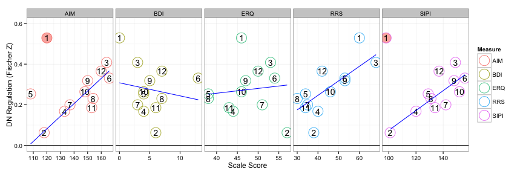

#### Total Scale Scores (with PANAS, without BDI)

##### Multiple Regression

```r
names <- c("SIPI", "RRS", "ERQ", "AIM", "PANAS_Positive", "PANAS_Negative")
brainbehavior.multiple(names, with_age_sex = FALSE)
```

```
##
## Call:
## lmrob(formula = f, data = df, maxit.scale = 500)
##
## Weighted Residuals:
##  [1]  0.08418 -0.06069 -0.06088 -0.08165  0.02660  0.05351  0.04824
##  [8]  0.00196 -0.05225 -0.01555 -0.04552  0.11610
##
## Coefficients:
##                 Estimate Std. Error t value Pr(>|t|)
## (Intercept)     0.191362   0.203802    0.94    0.391
## SIPI           -0.000305   0.001877   -0.16    0.877
## RRS             0.009965   0.002544    3.92    0.011 *
## ERQ            -0.008815   0.003516   -2.51    0.054 .
## AIM             0.000873   0.001735    0.50    0.636
## PANAS_Positive  0.000397   0.003911    0.10    0.923
## PANAS_Negative -0.002836   0.004632   -0.61    0.567
## ---
## Signif. codes:  0 '***' 0.001 '**' 0.01 '*' 0.05 '.' 0.1 ' ' 1
##
## Robust residual standard error: 0.0864
## Convergence in 12 IRWLS iterations
##
## Robustness weights:
##  one weight is ~= 1. The remaining 11 ones are summarized as
##    Min. 1st Qu.  Median    Mean 3rd Qu.    Max.
##   0.842   0.938   0.965   0.951   0.973   0.997
## Algorithmic parameters:
## tuning.chi         bb tuning.psi refine.tol    rel.tol  solve.tol
##   1.55e+00   5.00e-01   4.69e+00   1.00e-07   1.00e-07   1.00e-07
##      nResample         max.it       best.r.s       k.fast.s          k.max
##            500             50              2              1            200
##    maxit.scale      trace.lev            mts     compute.rd fast.s.large.n
##            500              0           1000              0           2000
##           psi   subsampling        method           cov
##    "bisquare" "nonsingular"          "MM" ".vcov.avar1"
## seed : int(0)
```

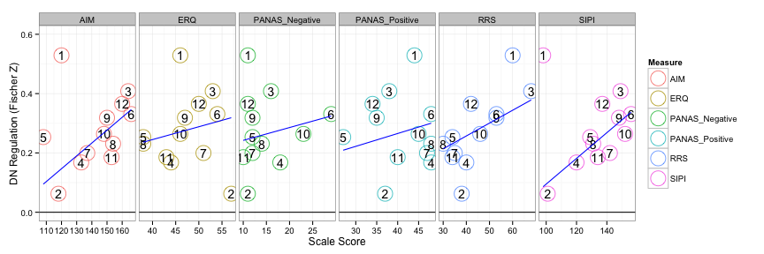

##### Single Regressions

Of course there is no point in re-running this here.

#### RRS SubScales

##### Multiple Regression

```r
names <- c("RRS_Brooding", "RRS_Reflection", "RRS_Depression")
brainbehavior.multiple(names, with_age_sex = FALSE)
```

```
##
## Call:
## lmrob(formula = f, data = df, maxit.scale = 500)
##
## Weighted Residuals:
##     Min      1Q  Median      3Q     Max
## -0.1661 -0.0305 -0.0116  0.0570  0.1341
##
## Coefficients:
##                Estimate Std. Error t value Pr(>|t|)
## (Intercept)    -0.05865    0.10439   -0.56     0.59
## RRS_Brooding    0.00764    0.01041    0.73     0.48
## RRS_Reflection  0.00752    0.00637    1.18     0.27
## RRS_Depression  0.00755    0.00770    0.98     0.36
##
## Robust residual standard error: 0.0996
## Convergence in 10 IRWLS iterations
##
## Robustness weights:
##  one weight is ~= 1. The remaining 11 ones are summarized as
##    Min. 1st Qu.  Median    Mean 3rd Qu.    Max.
##   0.762   0.923   0.972   0.941   0.995   0.999
## Algorithmic parameters:
## tuning.chi         bb tuning.psi refine.tol    rel.tol  solve.tol
##   1.55e+00   5.00e-01   4.69e+00   1.00e-07   1.00e-07   1.00e-07
##      nResample         max.it       best.r.s       k.fast.s          k.max
##            500             50              2              1            200
##    maxit.scale      trace.lev            mts     compute.rd fast.s.large.n
##            500              0           1000              0           2000
##           psi   subsampling        method           cov
##    "bisquare" "nonsingular"          "MM" ".vcov.avar1"
## seed : int(0)
```

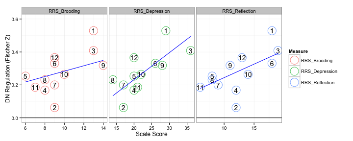

##### Single Regressions

```r
names <- c("RRS_Brooding", "RRS_Depression", "RRS_Reflection")
brainbehavior.single(names, with_age_sex = FALSE)
```

```
##
## Running regression for RRS_Brooding
##
## Call:
## lmrob(formula = f, data = df, maxit.scale = 500)
##
## Weighted Residuals:
##      Min       1Q   Median       3Q      Max
## -0.19849 -0.06178 -0.00752  0.07318  0.14777
##
## Coefficients:
##              Estimate Std. Error t value Pr(>|t|)
## (Intercept)   -0.0095     0.1110   -0.09    0.934
## RRS_Brooding   0.0301     0.0121    2.49    0.032 *
## ---
## Signif. codes:  0 '***' 0.001 '**' 0.01 '*' 0.05 '.' 0.1 ' ' 1
##
## Robust residual standard error: 0.109
## Convergence in 10 IRWLS iterations
##
## Robustness weights:
##  one weight is ~= 1. The remaining 11 ones are summarized as
##    Min. 1st Qu.  Median    Mean 3rd Qu.    Max.
##   0.722   0.927   0.963   0.932   0.983   0.998
## Algorithmic parameters:
## tuning.chi         bb tuning.psi refine.tol    rel.tol  solve.tol
##   1.55e+00   5.00e-01   4.69e+00   1.00e-07   1.00e-07   1.00e-07
##      nResample         max.it       best.r.s       k.fast.s          k.max
##            500             50              2              1            200
##    maxit.scale      trace.lev            mts     compute.rd fast.s.large.n
##            500              0           1000              0           2000
##           psi   subsampling        method           cov
##    "bisquare" "nonsingular"          "MM" ".vcov.avar1"
## seed : int(0)
##
##
## Running regression for RRS_Depression
##
## Call:
## lmrob(formula = f, data = df, maxit.scale = 500)
```

[output cut: 49 more lines]

```
##
## Robustness weights:
##  one weight is ~= 1. The remaining 11 ones are summarized as
##    Min. 1st Qu.  Median    Mean 3rd Qu.    Max.
##   0.514   0.899   0.966   0.902   0.982   0.997
## Algorithmic parameters:
## tuning.chi         bb tuning.psi refine.tol    rel.tol  solve.tol
##   1.55e+00   5.00e-01   4.69e+00   1.00e-07   1.00e-07   1.00e-07
##      nResample         max.it       best.r.s       k.fast.s          k.max
##            500             50              2              1            200
##    maxit.scale      trace.lev            mts     compute.rd fast.s.large.n
##            500              0           1000              0           2000
##           psi   subsampling        method           cov
##    "bisquare" "nonsingular"          "MM" ".vcov.avar1"
## seed : int(0)
```

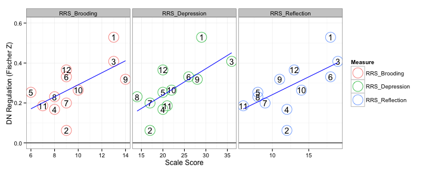

#### SIPI SubScales

##### Multiple Regression

```r
names <- c("SIPI_PAC", "SIPI_GFFD", "SIPI_PCD")
brainbehavior.multiple(names, with_age_sex = FALSE)
```

```
##
## Call:
## lmrob(formula = f, data = df, maxit.scale = 500)
##
## Weighted Residuals:
##       Min        1Q    Median        3Q       Max
## -0.070611 -0.033417  0.000531  0.047217  0.452550
##
## Coefficients:
##             Estimate Std. Error t value Pr(>|t|)
## (Intercept) -0.36204    0.23759   -1.52    0.166
## SIPI_PAC     0.00460    0.00381    1.21    0.261
## SIPI_GFFD    0.00515    0.00269    1.91    0.093 .
## SIPI_PCD     0.00406    0.00275    1.48    0.178
## ---
## Signif. codes:  0 '***' 0.001 '**' 0.01 '*' 0.05 '.' 0.1 ' ' 1
##
## Robust residual standard error: 0.101
## Convergence in 15 IRWLS iterations
##
## Robustness weights:
##  observation 1 is an outlier with |weight| <= 0.008 ( < 0.0083);
##  3 weights are ~= 1. The remaining 8 ones are
##     2     3     5     6     7    10    11    12
## 0.995 0.933 0.990 0.999 0.956 0.963 0.963 0.885
## Algorithmic parameters:
## tuning.chi         bb tuning.psi refine.tol    rel.tol  solve.tol
##   1.55e+00   5.00e-01   4.69e+00   1.00e-07   1.00e-07   1.00e-07
##      nResample         max.it       best.r.s       k.fast.s          k.max
##            500             50              2              1            200
##    maxit.scale      trace.lev            mts     compute.rd fast.s.large.n
##            500              0           1000              0           2000
##           psi   subsampling        method           cov
##    "bisquare" "nonsingular"          "MM" ".vcov.avar1"
## seed : int(0)
```

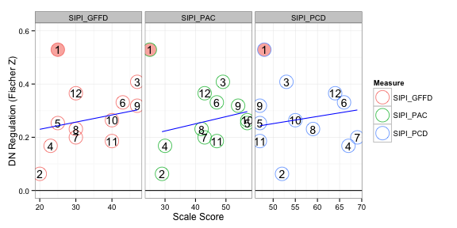

##### Single Regressions

```r
names <- c("SIPI_PAC", "SIPI_GFFD", "SIPI_PCD")
brainbehavior.single(names, with_age_sex = FALSE)
```

```
##
## Running regression for SIPI_PAC
##
## Call:
## lmrob(formula = f, data = df, maxit.scale = 500)
##
## Weighted Residuals:
##     Min      1Q  Median      3Q     Max
## -0.1373 -0.0530 -0.0269  0.0752  0.3444
##
## Coefficients:
##             Estimate Std. Error t value Pr(>|t|)
## (Intercept)   0.0895     0.5862    0.15     0.88
## SIPI_PAC      0.0038     0.0115    0.33     0.75
##
## Robust residual standard error: 0.106
## Convergence in 35 IRWLS iterations
##
## Robustness weights:
##    Min. 1st Qu.  Median    Mean 3rd Qu.    Max.
##   0.273   0.892   0.973   0.894   0.987   0.997
## Algorithmic parameters:
## tuning.chi         bb tuning.psi refine.tol    rel.tol  solve.tol
##   1.55e+00   5.00e-01   4.69e+00   1.00e-07   1.00e-07   1.00e-07
##      nResample         max.it       best.r.s       k.fast.s          k.max
##            500             50              2              1            200
##    maxit.scale      trace.lev            mts     compute.rd fast.s.large.n
##            500              0           1000              0           2000
##           psi   subsampling        method           cov
##    "bisquare" "nonsingular"          "MM" ".vcov.avar1"
## seed : int(0)
##
##
## Running regression for SIPI_GFFD
##
## Call:
## lmrob(formula = f, data = df, maxit.scale = 500)
##
## Weighted Residuals:
##      Min       1Q   Median       3Q      Max
```

[output cut: 44 more lines]

```
##
## Robustness weights:
##  one weight is ~= 1. The remaining 11 ones are summarized as
##    Min. 1st Qu.  Median    Mean 3rd Qu.    Max.
##   0.747   0.933   0.967   0.931   0.990   0.997
## Algorithmic parameters:
## tuning.chi         bb tuning.psi refine.tol    rel.tol  solve.tol
##   1.55e+00   5.00e-01   4.69e+00   1.00e-07   1.00e-07   1.00e-07
##      nResample         max.it       best.r.s       k.fast.s          k.max
##            500             50              2              1            200
##    maxit.scale      trace.lev            mts     compute.rd fast.s.large.n
##            500              0           1000              0           2000
##           psi   subsampling        method           cov
##    "bisquare" "nonsingular"          "MM" ".vcov.avar1"
## seed : int(0)
```

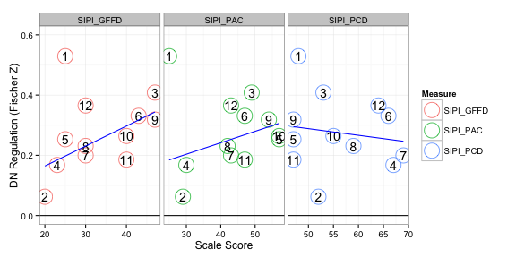

#### ERQ SubScales

##### Multiple Regression

```r
names <- c("ERQ_Reappraisal", "ERQ_Suppression")
brainbehavior.multiple(names, with_age_sex = FALSE)
```

```
##
## Call:
## lmrob(formula = f, data = df, maxit.scale = 500)
##
## Weighted Residuals:
##      Min       1Q   Median       3Q      Max
## -0.26544 -0.07081  0.00501  0.05991  0.23044
##
## Coefficients:
##                 Estimate Std. Error t value Pr(>|t|)
## (Intercept)      0.10682    0.52260    0.20     0.84
## ERQ_Reappraisal  0.00225    0.00943    0.24     0.82
## ERQ_Suppression  0.00690    0.01888    0.37     0.72
##
## Robust residual standard error: 0.116
## Convergence in 23 IRWLS iterations
##
## Robustness weights:
##  one weight is ~= 1. The remaining 11 ones are summarized as
##    Min. 1st Qu.  Median    Mean 3rd Qu.    Max.
##   0.579   0.932   0.959   0.905   0.991   0.999
## Algorithmic parameters:
## tuning.chi         bb tuning.psi refine.tol    rel.tol  solve.tol
##   1.55e+00   5.00e-01   4.69e+00   1.00e-07   1.00e-07   1.00e-07
##      nResample         max.it       best.r.s       k.fast.s          k.max
##            500             50              2              1            200
##    maxit.scale      trace.lev            mts     compute.rd fast.s.large.n
##            500              0           1000              0           2000
##           psi   subsampling        method           cov
##    "bisquare" "nonsingular"          "MM" ".vcov.avar1"
## seed : int(0)
```

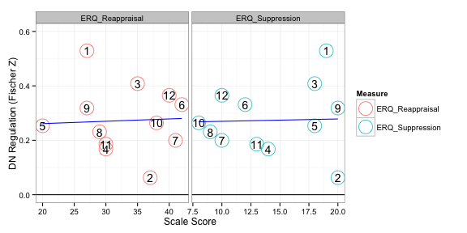

##### Single Regressions

```r
names <- c("ERQ_Reappraisal", "ERQ_Suppression")
brainbehavior.single(names, with_age_sex = FALSE)
```

```
##
## Running regression for ERQ_Reappraisal
##
## Call:
## lmrob(formula = f, data = df, maxit.scale = 500)
##
## Weighted Residuals:
##     Min      1Q  Median      3Q     Max
## -0.2083 -0.0740 -0.0166  0.0713  0.2526
##
## Coefficients:
##                  Estimate Std. Error t value Pr(>|t|)
## (Intercept)      0.291623   0.146853    1.99    0.075 .
## ERQ_Reappraisal -0.000561   0.004227   -0.13    0.897
## ---
## Signif. codes:  0 '***' 0.001 '**' 0.01 '*' 0.05 '.' 0.1 ' ' 1
##
## Robust residual standard error: 0.132
## Convergence in 8 IRWLS iterations
##
## Robustness weights:
##  one weight is ~= 1. The remaining 11 ones are summarized as
##    Min. 1st Qu.  Median    Mean 3rd Qu.    Max.
##   0.695   0.923   0.959   0.925   0.985   0.996
## Algorithmic parameters:
## tuning.chi         bb tuning.psi refine.tol    rel.tol  solve.tol
##   1.55e+00   5.00e-01   4.69e+00   1.00e-07   1.00e-07   1.00e-07
##      nResample         max.it       best.r.s       k.fast.s          k.max
##            500             50              2              1            200
##    maxit.scale      trace.lev            mts     compute.rd fast.s.large.n
##            500              0           1000              0           2000
##           psi   subsampling        method           cov
##    "bisquare" "nonsingular"          "MM" ".vcov.avar1"
## seed : int(0)
##
##
## Running regression for ERQ_Suppression
##
## Call:
## lmrob(formula = f, data = df, maxit.scale = 500)
```

[output cut: 13 more lines]

```
## Convergence in 10 IRWLS iterations
##
## Robustness weights:
##    Min. 1st Qu.  Median    Mean 3rd Qu.    Max.
##   0.726   0.939   0.971   0.933   0.993   0.999
## Algorithmic parameters:
## tuning.chi         bb tuning.psi refine.tol    rel.tol  solve.tol
##   1.55e+00   5.00e-01   4.69e+00   1.00e-07   1.00e-07   1.00e-07
##      nResample         max.it       best.r.s       k.fast.s          k.max
##            500             50              2              1            200
##    maxit.scale      trace.lev            mts     compute.rd fast.s.large.n
##            500              0           1000              0           2000
##           psi   subsampling        method           cov
##    "bisquare" "nonsingular"          "MM" ".vcov.avar1"
## seed : int(0)
```

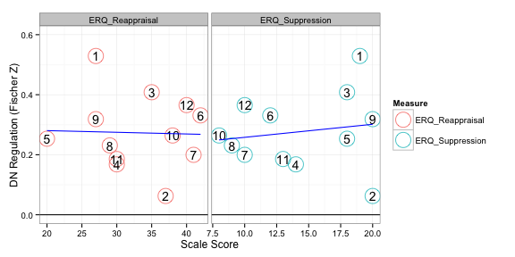

#### PANAS SubScales

##### Multiple Regression

```r
names <- c("PANAS_Positive", "PANAS_Negative")
brainbehavior.multiple(names, with_age_sex = FALSE)
```

```
##
## Call:
## lmrob(formula = f, data = df, maxit.scale = 500)
##
## Weighted Residuals:
##     Min      1Q  Median      3Q     Max
## -0.2008 -0.0582 -0.0140  0.0534  0.2954
##
## Coefficients:
##                Estimate Std. Error t value Pr(>|t|)
## (Intercept)     0.36230    0.17305    2.09    0.066 .
## PANAS_Positive -0.00425    0.00581   -0.73    0.484
## PANAS_Negative  0.00528    0.00598    0.88    0.400
## ---
## Signif. codes:  0 '***' 0.001 '**' 0.01 '*' 0.05 '.' 0.1 ' ' 1
##
## Robust residual standard error: 0.116
## Convergence in 8 IRWLS iterations
##
## Robustness weights:
##  one weight is ~= 1. The remaining 11 ones are summarized as
##    Min. 1st Qu.  Median    Mean 3rd Qu.    Max.
##   0.497   0.924   0.976   0.906   0.991   0.997
## Algorithmic parameters:
## tuning.chi         bb tuning.psi refine.tol    rel.tol  solve.tol
##   1.55e+00   5.00e-01   4.69e+00   1.00e-07   1.00e-07   1.00e-07
##      nResample         max.it       best.r.s       k.fast.s          k.max
##            500             50              2              1            200
##    maxit.scale      trace.lev            mts     compute.rd fast.s.large.n
##            500              0           1000              0           2000
##           psi   subsampling        method           cov
##    "bisquare" "nonsingular"          "MM" ".vcov.avar1"
## seed : int(0)
```

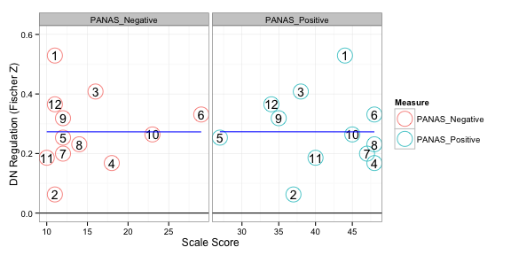

##### Single Regression

```r
names <- c("PANAS_Positive", "PANAS_Negative")
brainbehavior.single(names, with_age_sex = FALSE)
```

```
##
## Running regression for PANAS_Positive
##
## Call:
## lmrob(formula = f, data = df, maxit.scale = 500)
##
## Weighted Residuals:
##     Min      1Q  Median      3Q     Max
## -0.2167 -0.0693 -0.0158  0.0729  0.2615
##
## Coefficients:
##                Estimate Std. Error t value Pr(>|t|)
## (Intercept)     0.34103    0.14554    2.34    0.041 *
## PANAS_Positive -0.00167    0.00348   -0.48    0.642
## ---
## Signif. codes:  0 '***' 0.001 '**' 0.01 '*' 0.05 '.' 0.1 ' ' 1
##
## Robust residual standard error: 0.128
## Convergence in 8 IRWLS iterations
##
## Robustness weights:
##  one weight is ~= 1. The remaining 11 ones are summarized as
##    Min. 1st Qu.  Median    Mean 3rd Qu.    Max.
##   0.655   0.930   0.964   0.920   0.984   0.995
## Algorithmic parameters:
## tuning.chi         bb tuning.psi refine.tol    rel.tol  solve.tol
##   1.55e+00   5.00e-01   4.69e+00   1.00e-07   1.00e-07   1.00e-07
##      nResample         max.it       best.r.s       k.fast.s          k.max
##            500             50              2              1            200
##    maxit.scale      trace.lev            mts     compute.rd fast.s.large.n
##            500              0           1000              0           2000
##           psi   subsampling        method           cov
##    "bisquare" "nonsingular"          "MM" ".vcov.avar1"
## seed : int(0)
##
##
## Running regression for PANAS_Negative
##
## Call:
## lmrob(formula = f, data = df, maxit.scale = 500)
```

[output cut: 14 more lines]

```
##
## Robustness weights:
##  one weight is ~= 1. The remaining 11 ones are summarized as
##    Min. 1st Qu.  Median    Mean 3rd Qu.    Max.
##   0.652   0.920   0.970   0.922   0.988   0.996
## Algorithmic parameters:
## tuning.chi         bb tuning.psi refine.tol    rel.tol  solve.tol
##   1.55e+00   5.00e-01   4.69e+00   1.00e-07   1.00e-07   1.00e-07
##      nResample         max.it       best.r.s       k.fast.s          k.max
##            500             50              2              1            200
##    maxit.scale      trace.lev            mts     compute.rd fast.s.large.n
##            500              0           1000              0           2000
##           psi   subsampling        method           cov
##    "bisquare" "nonsingular"          "MM" ".vcov.avar1"
## seed : int(0)
```

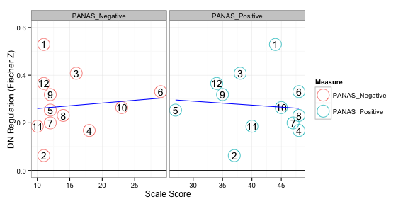